# Course Project : writeup

samrudha kelkar

Sunday, October 26, 2014

This is my submission towards Coursera Course on “Practical Machine Leraning” conducted by John Hopkins Bloomberg School of Public Health in Oct-Nov 2014

Training Model:

With the available training and testing data, I used **Random forest** method to train the model. I considered following things:

1.Predictors present in testing data

2.Typically “sufficient” sensors used in motion prediction + Gyrometer and accerometer data would be sufficient to train the model

3.Variance of the predictors

Pre-processing:

I used **PCA** method for preprocessing considering the large number of original predictors. *pcaComp factor* is chosen such that most of the variations are covered.

Summary of the model:

```
## Random Forest
##
## 15698 samples
##    29 predictor
##     5 classes: 'A', 'B', 'C', 'D', 'E'
##
## Pre-processing: principal component signal extraction, scaled, centered
## Resampling: Bootstrapped (25 reps)
##
## Summary of sample sizes: 15698, 15698, 15698, 15698, 15698, 15698, ...
##
## Resampling results across tuning parameters:
##
##   mtry  Accuracy  Kappa  Accuracy SD  Kappa SD
##    2    0.982     0.977  0.00293      0.00370
##   15    0.969     0.961  0.00419      0.00529
##   29    0.960     0.950  0.00661      0.00835
##
## Accuracy was used to select the optimal model using  the largest value.
## The final value used for the model was mtry = 2.
```

Confusion matrix thus generated is as follows:

```
## Confusion Matrix and Statistics
##
##           Reference
## Prediction    A    B    C    D    E
##          A 1112    3    0    0    0
##          B    1  739    4    0    0
##          C    0   10  704   13    0
##          D    0    0    7  632    3
##          E    0    0    0    2  694
##
## Overall Statistics
##
##                Accuracy : 0.989
##                  95% CI : (0.9853, 0.9921)
##     No Information Rate : 0.2836
##     P-Value [Acc > NIR] : < 2.2e-16
##
##                   Kappa : 0.9861
##  Mcnemar's Test P-Value : NA
##
## Statistics by Class:
##
##                      Class: A Class: B Class: C Class: D Class: E
## Sensitivity            0.9991   0.9827   0.9846   0.9768   0.9957
## Specificity            0.9989   0.9984   0.9928   0.9969   0.9994
## Pos Pred Value         0.9973   0.9933   0.9684   0.9844   0.9971
## Neg Pred Value         0.9996   0.9959   0.9966   0.9954   0.9991
## Prevalence             0.2836   0.1916   0.1822   0.1649   0.1776
## Detection Rate         0.2834   0.1883   0.1794   0.1611   0.1769
## Detection Prevalence   0.2841   0.1896   0.1853   0.1636   0.1774
## Balanced Accuracy      0.9990   0.9906   0.9887   0.9869   0.9975
```

It is said that Boosting combined with random forest produce better results.

I used information provided by boosting model about variance of predictors. Considering only high “informative” predictors I built another model.

Computation of this model was fast as lesser predictors were involved and accuracy was improved.

```
## Confusion Matrix and Statistics
##
##           Reference
## Prediction    A    B    C    D    E
##          A 1113    0    0    0    0
##          B    0  752    0    0    0
##          C    0    0  715    0    0
##          D    0    0    0  647    0
##          E    0    0    0    0  697
##
## Overall Statistics
##
##                Accuracy : 1
##                  95% CI : (0.9991, 1)
##     No Information Rate : 0.2836
##     P-Value [Acc > NIR] : < 2.2e-16
##
##                   Kappa : 1
##  Mcnemar's Test P-Value : NA
##
## Statistics by Class:
##
##                      Class: A Class: B Class: C Class: D Class: E
## Sensitivity            1.0000   1.0000   1.0000   1.0000   1.0000
## Specificity            1.0000   1.0000   1.0000   1.0000   1.0000
## Pos Pred Value         1.0000   1.0000   1.0000   1.0000   1.0000
## Neg Pred Value         1.0000   1.0000   1.0000   1.0000   1.0000
## Prevalence             0.2836   0.1916   0.1822   0.1649   0.1776
## Detection Rate         0.2836   0.1916   0.1822   0.1649   0.1776
## Detection Prevalence   0.2836   0.1916   0.1822   0.1649   0.1776
## Balanced Accuracy      1.0000   1.0000   1.0000   1.0000   1.0000
```

```
## Random Forest
##
## 15698 samples
##     9 predictor
##     5 classes: 'A', 'B', 'C', 'D', 'E'
##
## No pre-processing
## Resampling: Bootstrapped (25 reps)
##
## Summary of sample sizes: 15698, 15698, 15698, 15698, 15698, 15698, ...
##
## Resampling results across tuning parameters:
##
##   mtry  Accuracy  Kappa  Accuracy SD  Kappa SD
##   2     1         1      0.000149     0.000189
##   5     1         1      0.000140     0.000177
##   9     1         1      0.000173     0.000219
##
## Accuracy was used to select the optimal model using  the largest value.
## The final value used for the model was mtry = 2.
```

One of the characteristic observation is that totalAccelArm is always <50 for classe “A”:

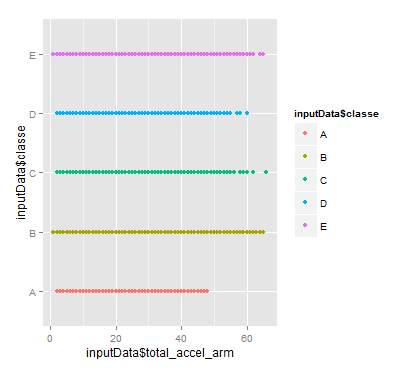